# AASD4015 Project 2 Builiing a Facial Object Detection System for Home Security by Transfer Learning

#### By Team 55: Chuen Kei Ho 101410183 & Ka Tsun Chan 101420274

### Problem Statement

#### We would like to build a personalized smart home system that recognizes and greets individuals when the system recognizes that they enter their own house. Traditional security systems and cameras lack the ability to recognize individuals and customize their responses. By building a face detection neural network, the system can provide a warm welcome and personalize the experience for the homeowner. Additionally, it can enhance home security by only allowing authorized individuals into the home. The proposed system aims to address the need for an intelligent, secure, and personalized home environment.

#### The proposed neural network architecture is using transfer learning from the VGG-16 model as the backbone and then adds a fully connected layer before the classification head as well as the bounding boxes regression output for identifying individuals

# 1. Setup and Get Data

### 1.1 Install Dependencies and Setup

```python
#install packages
#!pip install labelme tensorflow opencv-python matplotlib albumentations
```

### 1.2 Collect Images Using OpenCV

```python
import os
import time
import uuid
import cv2
```

```python
IMAGES_PATH = os.path.join('data','images')
number_images = 30
```

```python
cap = cv2.VideoCapture(1)
for imgnum in range(number_images):
    print('Collecting image {}'.format(imgnum))
    ret, frame = cap.read()
    imgname = os.path.join(IMAGES_PATH,f'{str(uuid.uuid1())}.jpg')
    cv2.imwrite(imgname, frame)
    cv2.imshow('frame', frame)
    time.sleep(0.5)

    if cv2.waitKey(1) & 0xFF == ord('q'):
        break
cap.release()
cv2.destroyAllWindows()
```

### 1.3 Annotate Images with LabelMe

```python
#!labelme
```

# 2. Review Dataset and Build Image Loading Function

### 2.1 Import TF and Deps

```python
import tensorflow as tf
import json
import numpy as np
from matplotlib import pyplot as plt
```

### 2.2 Limit GPU Memory Growth

```python
# Avoid OOM errors by setting GPU Memory Consumption Growth
gpus = tf.config.experimental.list_physical_devices('GPU')
for gpu in gpus:
    tf.config.experimental.set_memory_growth(gpu, True)
```

```python
tf.config.list_physical_devices('GPU')
```

```
[PhysicalDevice(name='/physical_device:GPU:0', device_type='GPU')]
```

```python
%ls
```

```
FaceDetection_Deep_Learning_Final.ipynb
aug_data/
data/
```

### 2.3 Load Image into TF Data Pipeline

```python
#images = tf.data.Dataset.list_files('/data/images/*.jpg')
```

```python
#images.as_numpy_iterator().next()
```

```python
def load_image(x):
    byte_img = tf.io.read_file(x)
    img = tf.io.decode_jpeg(byte_img)
    return img
```

```python
#images = images.map(load_image)
```

# 3. Partition Unaugmented Data

##### 3.1 MANUALLY SPLT DATA INTO TRAIN TEST AND VAL

```python
50*.7 # 35 to train
```

```python
50*.15 # 8 and 7 to test and val
```

### 3.2 Move the Matching Labels

```python
# for folder in ['train','test','val']:
#     for file in os.listdir(os.path.join('data', folder, 'images')):

#         filename = file.split('.')[0]+'.json'
#         existing_filepath = os.path.join('data','labels', filename)
#         if os.path.exists(existing_filepath):
#             new_filepath = os.path.join('data',folder,'labels',filename)
#             os.replace(existing_filepath, new_filepath)
```

# 4. Apply Image Augmentation on Images and Labels using Albumentations

### 4.1 Setup Albumentations Transform Pipeline

```python
import albumentations as alb
```

```python
augmentor = alb.Compose([alb.RandomCrop(width=450, height=450),
                         alb.HorizontalFlip(p=0.5),
                         alb.RandomBrightnessContrast(p=0.2),
                         alb.RandomGamma(p=0.2),
                         alb.RGBShift(p=0.2),
                         alb.VerticalFlip(p=0.5)],
                       bbox_params=alb.BboxParams(format='albumentations',
                                                  label_fields=['class_labels']))
```

### 4.2 Load a Test Image and Annotation with OpenCV and JSON

```python
img = cv2.imread(os.path.join('/Users/ktchan33/Adv_Math_Proj2_Team55/Final/data','train', 'images','0ac3174f-d441-11ed-aa5a-046c591b963e.jpg'))
```

```python
with open(os.path.join('/Users/ktchan33/Adv_Math_Proj2_Team55/Final/data', 'train', 'labels', '0ac3174f-d441-11ed-aa5a-046c591b963e.json'), 'r') as f:
    label = json.load(f)
```

```python
label['shapes'][0]['points']
```

```
[[196.48514851485146, 94.95049504950495],
 [361.33663366336634, 321.1881188118812]]
```

### 4.3 Extract Coordinates and Rescale to Match Image Resolution

```python
coords = [0,0,0,0]
coords[0] = label['shapes'][0]['points'][0][0]
coords[1] = label['shapes'][0]['points'][0][1]
coords[2] = label['shapes'][0]['points'][1][0]
coords[3] = label['shapes'][0]['points'][1][1]
```

```python
coords
```

```
[196.48514851485146, 94.95049504950495, 361.33663366336634, 321.1881188118812]
```

```python
coords = list(np.divide(coords, [640,480,640,480]))
```

```python
coords
```

```
[0.3070080445544554,
 0.1978135313531353,
 0.5645884900990099,
 0.6691419141914192]
```

### 4.4 Apply Augmentations and View Results

```python
augmented = augmentor(image=img, bboxes=[coords], class_labels=['Ken'])
```

```python
augmented['bboxes'][0][2:]
```

```
(0.6407480748074807, 0.7137513751375139)
```

```python
augmented['bboxes']
```

```
[(0.27441144114411437,
  0.211001100110011,
  0.6407480748074807,
  0.7137513751375139)]
```

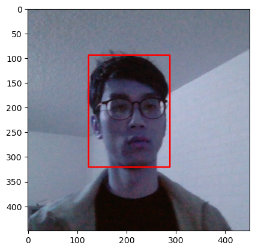

```python
##draw a bounding box around the face!
cv2.rectangle(augmented['image'],
              tuple(np.multiply(augmented['bboxes'][0][:2], [450,450]).astype(int)),
              tuple(np.multiply(augmented['bboxes'][0][2:], [450,450]).astype(int)),
                    (255,0,0), 2)

plt.imshow(augmented['image'])
```

# 5. Build and Run Augmentation Pipeline

### 5.1 Run Augmentation Pipeline

```python
for partition in ['train','test','val']:
    for image in os.listdir(os.path.join('data', partition, 'images')):
        img = cv2.imread(os.path.join('data', partition, 'images', image))

        coords = [0,0,0.00001,0.00001]
        label_path = os.path.join('data', partition, 'labels', f'{image.split(".")[0]}.json')
        if os.path.exists(label_path):
            with open(label_path, 'r') as f:
                label = json.load(f)

            coords[0] = label['shapes'][0]['points'][0][0]
            coords[1] = label['shapes'][0]['points'][0][1]
            coords[2] = label['shapes'][0]['points'][1][0]
            coords[3] = label['shapes'][0]['points'][1][1]
            coords = list(np.divide(coords, [640,480,640,480]))

        try:
            for x in range(60):
                augmented = augmentor(image=img, bboxes=[coords], class_labels=['Ken'])
                cv2.imwrite(os.path.join('aug_data', partition, 'images', f'{image.split(".")[0]}.{x}.jpg'), augmented['image'])

                annotation = {}
                annotation['image'] = image

                if os.path.exists(label_path):
                    if len(augmented['bboxes']) == 0:
                        annotation['bbox'] = [0,0,0,0]
                        annotation['class'] = 0
                    else:
                        annotation['bbox'] = augmented['bboxes'][0]
                        annotation['class'] = 1
                else:
                    annotation['bbox'] = [0,0,0,0]
                    annotation['class'] = 0


                with open(os.path.join('aug_data', partition, 'labels', f'{image.split(".")[0]}.{x}.json'), 'w') as f:
                    json.dump(annotation, f)

        except Exception as e:
            print(e)
```

### 5.2 Load Augmented Images to Tensorflow Dataset

```python
train_images = tf.data.Dataset.list_files('/Users/ktchan33/Adv_Math_Proj2_Team55/Final/aug_data/train/images/*.jpg', shuffle=False)
train_images = train_images.map(load_image)
train_images = train_images.map(lambda x: tf.image.resize(x, (120,120)))
train_images = train_images.map(lambda x: x/255)
```

```
Metal device set to: Apple M1 Pro

systemMemory: 16.00 GB
maxCacheSize: 5.33 GB
```

```
2023-04-06 22:56:19.602624: I tensorflow/core/common_runtime/pluggable_device/pluggable_device_factory.cc:305] Could not identify NUMA node of platform GPU ID 0, defaulting to 0. Your kernel may not have been built with NUMA support.
2023-04-06 22:56:19.603379: I tensorflow/core/common_runtime/pluggable_device/pluggable_device_factory.cc:271] Created TensorFlow device (/job:localhost/replica:0/task:0/device:GPU:0 with 0 MB memory) -> physical PluggableDevice (device: 0, name: METAL, pci bus id: <undefined>)
```

```python
test_images = tf.data.Dataset.list_files('/Users/ktchan33/Adv_Math_Proj2_Team55/Final/aug_data/test/images/*.jpg', shuffle=False)
test_images = test_images.map(load_image)
test_images = test_images.map(lambda x: tf.image.resize(x, (120,120)))
test_images = test_images.map(lambda x: x/255)
```

```python
val_images = tf.data.Dataset.list_files('/Users/ktchan33/Adv_Math_Proj2_Team55/Final/aug_data/val/images/*.jpg', shuffle=False)
val_images = val_images.map(load_image)
val_images = val_images.map(lambda x: tf.image.resize(x, (120,120)))
val_images = val_images.map(lambda x: x/255)
```

```python
train_images.as_numpy_iterator().next()
```

```
array([[[0.64705884, 0.62352943, 0.5735294 ],
        [0.652451  , 0.6254902 , 0.5838235 ],
        [0.6369485 , 0.6052696 , 0.5627451 ],
        ...,
        [0.18314952, 0.19491422, 0.23020834],
        [0.15208334, 0.16482843, 0.21158089],
        [0.17015931, 0.17984068, 0.22843137]],

       [[0.6589461 , 0.6357843 , 0.56599265],
        [0.6603554 , 0.6288603 , 0.5779412 ],
        [0.65496325, 0.6157476 , 0.56868875],
        ...,
        [0.17591912, 0.17542893, 0.21366422],
        [0.17248775, 0.17150736, 0.21807598],
        [0.1754902 , 0.18039216, 0.2245098 ]],

       [[0.6653799 , 0.6261642 , 0.5791054 ],
        [0.67150736, 0.6322917 , 0.593076  ],
        [0.65778184, 0.61856616, 0.5793505 ],
        ...,
        [0.16960785, 0.15784314, 0.19313726],
        [0.17996323, 0.17604166, 0.20055147],
        [0.21685049, 0.21537991, 0.24908088]],

       ...,

       [[0.6064951 , 0.55306375, 0.51960784],
        [0.60765934, 0.55422795, 0.5498162 ],
        [0.59319854, 0.5500613 , 0.52751225],
        ...,
        [0.5583946 , 0.5074142 , 0.4721201 ],
        [0.5416667 , 0.49068627, 0.45882353],
        [0.55202204, 0.50104165, 0.46721813]],

       [[0.59050244, 0.5389093 , 0.5107843 ],
        [0.5752451 , 0.5239583 , 0.5018382 ],
        [0.5672181 , 0.52751225, 0.49368873],
        ...,
        [0.5529412 , 0.5019608 , 0.46666667],
        [0.54509807, 0.49068627, 0.45539215],
        [0.55422795, 0.5015931 , 0.46666667]],

       [[0.54840684, 0.5047794 , 0.4685049 ],
        [0.55667895, 0.5223652 , 0.48216912],
        [0.59319854, 0.55398285, 0.51047796],
        ...,
        [0.5405024 , 0.49050245, 0.44001225],
        [0.5411765 , 0.49117646, 0.4406863 ],
        [0.53088236, 0.48272058, 0.43731618]]], dtype=float32)
```

# 6. Prepare Labels

### 6.1 Build Label Loading Function

```python
def load_labels(label_path):
    with open(label_path.numpy(), 'r', encoding = "utf-8") as f:
        label = json.load(f)

    return [label['class']], label['bbox']
```

### 6.2 Load Labels to Tensorflow Dataset

```python
train_labels = tf.data.Dataset.list_files('/Users/ktchan33/Adv_Math_Proj2_Team55/Final/aug_data/train/labels/*.json', shuffle=False)
train_labels = train_labels.map(lambda x: tf.py_function(load_labels, [x], [tf.uint8, tf.float16]))
```

```python
test_labels = tf.data.Dataset.list_files('/Users/ktchan33/Adv_Math_Proj2_Team55/Final/aug_data/test/labels/*.json', shuffle=False)
test_labels = test_labels.map(lambda x: tf.py_function(load_labels, [x], [tf.uint8, tf.float16]))
```

```python
val_labels = tf.data.Dataset.list_files('/Users/ktchan33/Adv_Math_Proj2_Team55/Final/aug_data/val/labels/*.json', shuffle=False)
val_labels = val_labels.map(lambda x: tf.py_function(load_labels, [x], [tf.uint8, tf.float16]))
```

```python
train_labels.as_numpy_iterator().next()
```

```
2023-04-06 22:56:34.026584: W tensorflow/core/platform/profile_utils/cpu_utils.cc:128] Failed to get CPU frequency: 0 Hz
```

```
(array([1], dtype=uint8),
 array([0.576 , 0.2064, 0.93  , 0.7236], dtype=float16))
```

# 7. Combine Label and Image Samples

### 7.1 Check Partition Lengths

```python
len(train_images), len(train_labels), len(test_images), len(test_labels), len(val_images), len(val_labels)
```

```
(2100, 2100, 480, 480, 420, 420)
```

### 7.2 Create Final Datasets (Images/Labels)

```python
train = tf.data.Dataset.zip((train_images, train_labels))
train = train.shuffle(5000)
train = train.batch(8)
train = train.prefetch(4)
```

```python
test = tf.data.Dataset.zip((test_images, test_labels))
test = test.shuffle(1300)
test = test.batch(8)
test = test.prefetch(4)
```

```python
val = tf.data.Dataset.zip((val_images, val_labels))
val = val.shuffle(1000)
val = val.batch(8)
val = val.prefetch(4)
```

```python
train.as_numpy_iterator().next()[1]
```

```
(array([[1],
        [1],
        [1],
        [1],
        [1],
        [0],
        [1],
        [0]], dtype=uint8),
 array([[0.693  , 0.3262 , 0.991  , 0.739  ],
        [0.448  , 0.1678 , 0.842  , 0.643  ],
        [0.1432 , 0.11707, 0.5513 , 0.689  ],
        [0.284  , 0.4766 , 0.7393 , 0.999  ],
        [0.8276 , 0.2908 , 1.     , 0.733  ],
        [0.     , 0.     , 0.     , 0.     ],
        [0.2683 , 0.34   , 0.5674 , 0.6304 ],
        [0.     , 0.     , 0.     , 0.     ]], dtype=float16))
```

### 7.3 View Images and Annotations

```python
data_samples = train.as_numpy_iterator()
```

```python
res = data_samples.next()
```

```
Clipping input data to the valid range for imshow with RGB data ([0..1] for floats or [0..255] for integers).
Clipping input data to the valid range for imshow with RGB data ([0..1] for floats or [0..255] for integers).
Clipping input data to the valid range for imshow with RGB data ([0..1] for floats or [0..255] for integers).
Clipping input data to the valid range for imshow with RGB data ([0..1] for floats or [0..255] for integers).
```

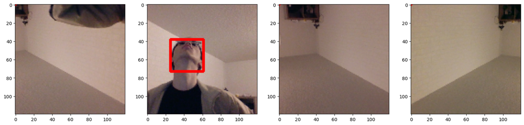

```python
fig, ax = plt.subplots(ncols=4, figsize=(20,20))
for idx in range(4):
    sample_image = res[0][idx]
    sample_coords = res[1][1][idx]

    cv2.rectangle(sample_image,
                  tuple(np.multiply(sample_coords[:2], [120,120]).astype(int)),
                  tuple(np.multiply(sample_coords[2:], [120,120]).astype(int)),
                        (255,0,0), 2)

    ax[idx].imshow(sample_image)
```

# 8. Build Deep Learning using the Functional API

### 8.1 Import Layers and Base Network

```python
from tensorflow.keras.models import Model
from tensorflow.keras.layers import Input, Conv2D, Dense, GlobalMaxPooling2D
from tensorflow.keras.applications import VGG16
```

### 8.2 Download VGG16

```python
vgg = VGG16(include_top=False)
```

```python
vgg.summary()
```

```
Model: "vgg16"
_________________________________________________________________
 Layer (type)                Output Shape              Param #
=================================================================
 input_1 (InputLayer)        [(None, None, None, 3)]   0

 block1_conv1 (Conv2D)       (None, None, None, 64)    1792

 block1_conv2 (Conv2D)       (None, None, None, 64)    36928

 block1_pool (MaxPooling2D)  (None, None, None, 64)    0

 block2_conv1 (Conv2D)       (None, None, None, 128)   73856

 block2_conv2 (Conv2D)       (None, None, None, 128)   147584

 block2_pool (MaxPooling2D)  (None, None, None, 128)   0

 block3_conv1 (Conv2D)       (None, None, None, 256)   295168

 block3_conv2 (Conv2D)       (None, None, None, 256)   590080

 block3_conv3 (Conv2D)       (None, None, None, 256)   590080

 block3_pool (MaxPooling2D)  (None, None, None, 256)   0

 block4_conv1 (Conv2D)       (None, None, None, 512)   1180160

 block4_conv2 (Conv2D)       (None, None, None, 512)   2359808

 block4_conv3 (Conv2D)       (None, None, None, 512)   2359808

 block4_pool (MaxPooling2D)  (None, None, None, 512)   0

 block5_conv1 (Conv2D)       (None, None, None, 512)   2359808

 block5_conv2 (Conv2D)       (None, None, None, 512)   2359808

 block5_conv3 (Conv2D)       (None, None, None, 512)   2359808

 block5_pool (MaxPooling2D)  (None, None, None, 512)   0

=================================================================
Total params: 14,714,688
Trainable params: 14,714,688
Non-trainable params: 0
_________________________________________________________________
```

### 8.3 Build instance of Network

```python
def build_model():
    input_layer = Input(shape=(120,120,3))

    vgg = VGG16(include_top=False)(input_layer)

    # Classification Model
    f1 = GlobalMaxPooling2D()(vgg)
    class1 = Dense(2048, activation='relu')(f1)
    class2 = Dense(1, activation='sigmoid')(class1)

    # Bounding box model
    f2 = GlobalMaxPooling2D()(vgg)
    regress1 = Dense(2048, activation='relu')(f2)
    regress2 = Dense(4, activation='sigmoid')(regress1)

    facetracker = Model(inputs=input_layer, outputs=[class2, regress2])
    return facetracker
```

### 8.4 Test out Neural Network

```python
facetracker = build_model()
```

```python
facetracker.summary()
```

```
Model: "model"
__________________________________________________________________________________________________
 Layer (type)                   Output Shape         Param #     Connected to
==================================================================================================
 input_2 (InputLayer)           [(None, 120, 120, 3  0           []
                                )]

 vgg16 (Functional)             (None, None, None,   14714688    ['input_2[0][0]']
                                512)

 global_max_pooling2d (GlobalMa  (None, 512)         0           ['vgg16[0][0]']
 xPooling2D)

 global_max_pooling2d_1 (Global  (None, 512)         0           ['vgg16[0][0]']
 MaxPooling2D)

 dense (Dense)                  (None, 2048)         1050624     ['global_max_pooling2d[0][0]']

 dense_2 (Dense)                (None, 2048)         1050624     ['global_max_pooling2d_1[0][0]']

 dense_1 (Dense)                (None, 1)            2049        ['dense[0][0]']

 dense_3 (Dense)                (None, 4)            8196        ['dense_2[0][0]']

==================================================================================================
Total params: 16,826,181
Trainable params: 16,826,181
Non-trainable params: 0
__________________________________________________________________________________________________
```

```python
X, y = train.as_numpy_iterator().next()
```

```python
X.shape
```

```
(8, 120, 120, 3)
```

```python
classes, coords = facetracker.predict(X)
```

```
2023-04-06 22:57:08.933373: I tensorflow/core/grappler/optimizers/custom_graph_optimizer_registry.cc:113] Plugin optimizer for device_type GPU is enabled.
```

```python
classes, coords
```

```
(array([[0.6161636 ],
        [0.6828832 ],
        [0.7713778 ],
        [0.75226134],
        [0.7701601 ],
        [0.774099  ],
        [0.76026464],
        [0.63874876]], dtype=float32),
 array([[0.5190163 , 0.44104347, 0.37839836, 0.6554678 ],
        [0.57967824, 0.46843278, 0.47614464, 0.6938204 ],
        [0.5891725 , 0.5786507 , 0.34447563, 0.59746075],
        [0.52497977, 0.54347646, 0.3794577 , 0.6302284 ],
        [0.55178803, 0.50596905, 0.40876117, 0.65016955],
        [0.53388566, 0.43292654, 0.32824472, 0.78418356],
        [0.5530813 , 0.5085002 , 0.3585959 , 0.7020149 ],
        [0.53812873, 0.55086565, 0.40261534, 0.6555259 ]], dtype=float32))
```

# 9. Define Losses and Optimizers

### 9.1 Define Optimizer and LR

```python
lr_schedule = tf.keras.optimizers.schedules.ExponentialDecay(
    initial_learning_rate=0.0001,
    decay_steps=10000,
    decay_rate=0.9)
```

```python
opt = tf.keras.optimizers.Adam(learning_rate=lr_schedule)
```

### 9.2 Create Localization Loss and Classification Loss

```python
def localization_loss(y_true, yhat):
    delta_coord = tf.reduce_sum(tf.square(y_true[:,:2] - yhat[:,:2]))

    h_true = y_true[:,3] - y_true[:,1]
    w_true = y_true[:,2] - y_true[:,0]

    h_pred = yhat[:,3] - yhat[:,1]
    w_pred = yhat[:,2] - yhat[:,0]

    delta_size = tf.reduce_sum(tf.square(w_true - w_pred) + tf.square(h_true-h_pred))

    return delta_coord + delta_size
```

```python
classloss = tf.keras.losses.BinaryCrossentropy()
regressloss = localization_loss
```

### 9.3 Test out Loss Metrics

```python
localization_loss(y[1], coords)
```

```
<tf.Tensor: shape=(), dtype=float32, numpy=3.9562774>
```

```python
classloss(y[0], classes)
```

```
<tf.Tensor: shape=(), dtype=float32, numpy=0.5412642>
```

```python
regressloss(y[1], coords)
```

[output not shown]

# 10. Train Neural Network

### 10.1 Create Custom Model Class

```python
class FaceTracker(Model):
    def __init__(self, eyetracker,  **kwargs):
        super().__init__(**kwargs)
        self.model = eyetracker

    def compile(self, opt, classloss, localizationloss, **kwargs):
        super().compile(**kwargs)
        self.closs = classloss
        self.lloss = localizationloss
        self.opt = opt

    def train_step(self, batch, **kwargs):

        X, y = batch

        with tf.GradientTape() as tape:
            classes, coords = self.model(X, training=True)

            batch_classloss = self.closs(y[0], classes)
            batch_localizationloss = self.lloss(tf.cast(y[1], tf.float32), coords)

            total_loss = batch_localizationloss+0.5*batch_classloss

            grad = tape.gradient(total_loss, self.model.trainable_variables)

        opt.apply_gradients(zip(grad, self.model.trainable_variables))

        return {"total_loss":total_loss, "class_loss":batch_classloss, "regress_loss":batch_localizationloss}

    def test_step(self, batch, **kwargs):
        X, y = batch

        classes, coords = self.model(X, training=False)

        batch_classloss = self.closs(y[0], classes)
        batch_localizationloss = self.lloss(tf.cast(y[1], tf.float32), coords)
        total_loss = batch_localizationloss+0.5*batch_classloss

        return {"total_loss":total_loss, "class_loss":batch_classloss, "regress_loss":batch_localizationloss}

    def call(self, X, **kwargs):
        return self.model(X, **kwargs)
```

```python
model = FaceTracker(facetracker)
```

```python
model.compile(opt, classloss, regressloss)
```

### 10.2 Train

```python
logdir='logs'
```

```python
hist = model.fit(train, epochs=50, validation_data=val)
```

```
2023-04-06 22:59:04.882251: I tensorflow/core/grappler/optimizers/custom_graph_optimizer_registry.cc:113] Plugin optimizer for device_type GPU is enabled.
```

### 10.3 Plot Performance

```python
hist.history
```

[output not shown]

[output cut: 245 more lines]

[output not shown]

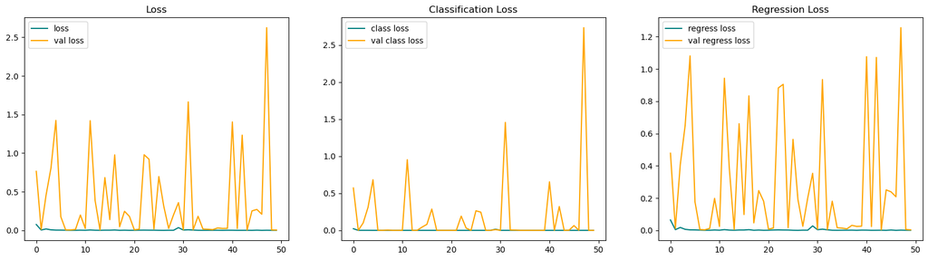

```python
fig, ax = plt.subplots(ncols=3, figsize=(20,5))

ax[0].plot(hist.history['total_loss'], color='teal', label='loss')
ax[0].plot(hist.history['val_total_loss'], color='orange', label='val loss')
ax[0].title.set_text('Loss')
ax[0].legend()

ax[1].plot(hist.history['class_loss'], color='teal', label='class loss')
ax[1].plot(hist.history['val_class_loss'], color='orange', label='val class loss')
ax[1].title.set_text('Classification Loss')
ax[1].legend()

ax[2].plot(hist.history['regress_loss'], color='teal', label='regress loss')
ax[2].plot(hist.history['val_regress_loss'], color='orange', label='val regress loss')
ax[2].title.set_text('Regression Loss')
ax[2].legend()

plt.show()
```

# 11. Make Predictions

### 11.1 Make Predictions on Test Set

```python
test_data = test.as_numpy_iterator()
```

```python
test_sample = test_data.next()
```

```python
yhat = facetracker.predict(test_sample[0])
```

```
Clipping input data to the valid range for imshow with RGB data ([0..1] for floats or [0..255] for integers).
Clipping input data to the valid range for imshow with RGB data ([0..1] for floats or [0..255] for integers).
```

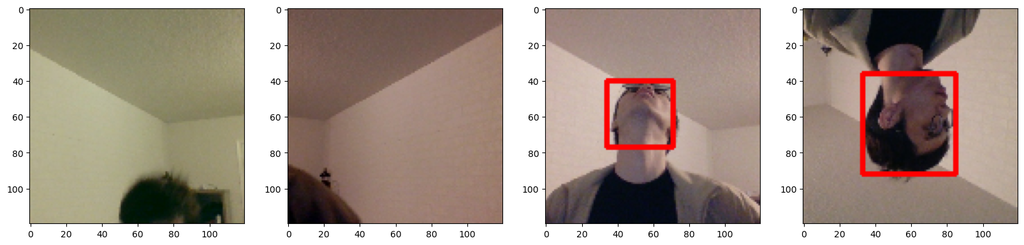

```python
fig, ax = plt.subplots(ncols=4, figsize=(20,20))
for idx in range(4):
    sample_image = test_sample[0][idx]
    sample_coords = yhat[1][idx]

    if yhat[0][idx] > 0.9:
        cv2.rectangle(sample_image,
                      tuple(np.multiply(sample_coords[:2], [120,120]).astype(int)),
                      tuple(np.multiply(sample_coords[2:], [120,120]).astype(int)),
                            (255,0,0), 2)

    ax[idx].imshow(sample_image)
```

### 11.2| Real Time Detection

```python
cap = cv2.VideoCapture(0)
print(cap.isOpened())
width = int(cap.get(cv2.CAP_PROP_FRAME_WIDTH))
height = int(cap.get(cv2.CAP_PROP_FRAME_HEIGHT))

while cap.isOpened() or True:
    _ , frame = cap.read()
    frame = frame[int(height/2)-500:int(height/2)+500, int(width/2)-500:int(width/2)+500, :]

    rgb = cv2.cvtColor(frame, cv2.COLOR_BGR2RGB)
    resized = tf.image.resize(rgb, (120,120))

    yhat = facetracker.predict(np.expand_dims(resized/255,0))
    sample_coords = yhat[1][0]

    if yhat[0] > 0.5:
        # Controls the main rectangle
        cv2.rectangle(frame,
                      tuple(np.multiply(sample_coords[:2], [1000, 1000]).astype(int)),
                      tuple(np.multiply(sample_coords[2:], [1000, 1000]).astype(int)),
                            (255,0,0), 2)
        # Controls the label rectangle
        cv2.rectangle(frame,
                      tuple(np.add(np.multiply(sample_coords[:2], [1000,1000]).astype(int),
                                    [0,-30])),
                      tuple(np.add(np.multiply(sample_coords[:2], [1000,1000]).astype(int),
                                    [80,0])),
                            (255,0,0), -1)

        # Controls the text rendered
        cv2.putText(frame, 'Ken', tuple(np.add(np.multiply(sample_coords[:2], [1000,1000]).astype(int),
                                               [0,-5])),
                    cv2.FONT_HERSHEY_SIMPLEX, 1, (255,255,255), 2, cv2.LINE_AA)

    cv2.imshow('EyeTrack', frame)

    if cv2.waitKey(1) & 0xFF == ord('q'):
        break
cap.release()
cv2.destroyAllWindows()
```

```
True
```

### Loss Against Epoch

#### It is unknown why the validation loss fluctuate for both classification and regression. We tried to adjust the learning rate as well as the learning rate decay in the learning rate exponential scheduler. It may suggest that 50 epochs is already too much and there are some sort of overfitting.

### Model prediction

#### The model is capable of recognizing human-face like me. However, when we try to apply the model to images with other people not in the dataset, the model fails to distinguish them from me and still believes other human faces are me, which is the only face included in the training set.

#### This illustrates that facial recognition is too complex for a simple model architecture to handle. Especially human faces within the same race usually shared similar features. Even with the difference in hairstyles, skin color, the shape of the face as well as the slight difference in eyes, nose, and ears, it is not enough for the VGG-16 model to distinguish them.

#### Therefore, a proposed solution would be to use a more advanced and state-of-the-art model architecture to achieve this objective of human facial recognition, for example, YOLOv5x.